# Techniki Wizualizacji Danych - PD3

Patryk Wróbel

**Cel zadania**

Celem zadania jest znalezienie w dowolnym artykule z 2018 roku złego wykresu i przygotowanie jego własnej wersji z uzasadnieniem wprowadzonych poprawek.

**Wybór wykresu**

Wybrany wykres pochodzi ze strony prezentującej dane dotyczące przeszczepów i dawców narządów z bieżącego roku. Przedstawia on liczbę pobranych w tym roku do przeszczepu narządów.

[figure not shown]

Wykres posiada kilka cech świadczących o jego błędnej konstrukcji. Przede wszystkim to wykres trójwymiarowy, co utrudnia odczytywanie wartości słupków z osi. Na wykresie nie widać proporcji w wielkości słupków (np. słupek odpowiadający przeszczepom nerki wcale nie jest 3 razy dłuższy od słupka wątroby). Niepoprawnie narysowana jest też oś Y (nie ma żadnego uzasadnienia, dla którego oś powinna się zaczynać od 20, a nie od 0). Poza tym maksymalna wyróżniona na osi Y wartość wynosi 470, podczas gdy najwyższy słupek prezentuje wartość 660 - na wykresie nie widać tej różnicy. Gdyby nie naniesione na wykres labele z dokładnymi wartościami liczbowymi, wyciągnięcie tych informacji z wykresu byłoby praktycznie niemożliwe.

Link do materiału: https://www.poltransplant.org.pl/statystyka_2018.html .

**Poprawiony wykres**

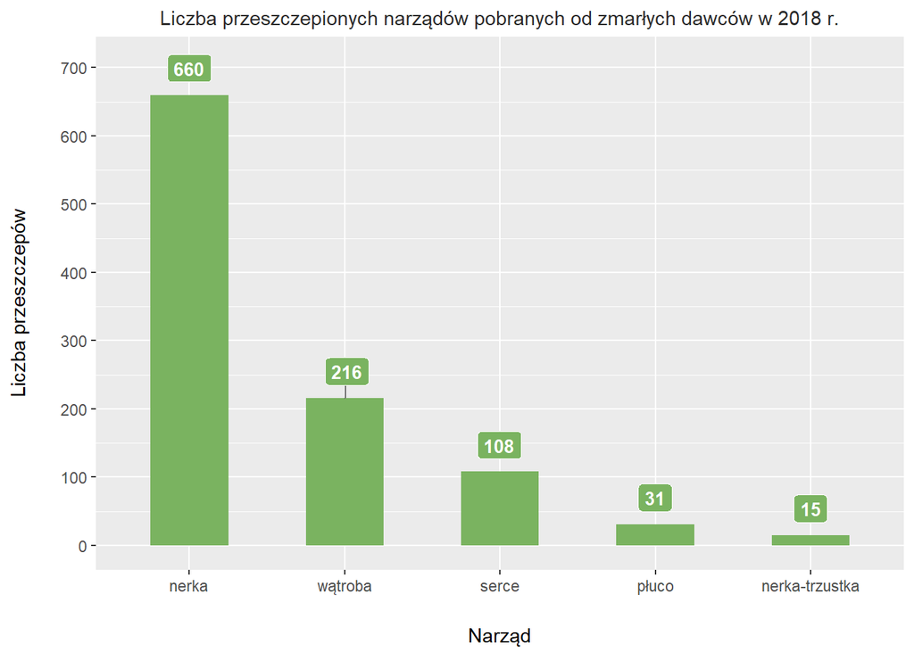

W nowej wersji wykresu usunięte też zostały osobne kolory dla każdego narządu, ponieważ błędnie sugerowały one wnoszenie do wykresu jakiejś dodatkowej informacji, a słupki narządów zostały uporządkowane w kolejności od największej liczby przeszczepów do najmniejszej.